# Variable Selection: Regional Diversity RF Models

Britta Schumacher

Last updated: 20 May, 2021

## Load data

```r
library(dplyr)
library(tidyverse)
library(ggcorrplot)
library(ranger)
library(gbm)
library(verification)
library(caret)
library(e1071)
library(EZtune)
library(spdplyr)
library(sp)
```

```r
div <- readRDS("./data/divers_classif_data.RDS")
div_reclass <- readRDS("./data/diversity_calcs_010921.RDS") %>% filter(YEAR %in% c(2012, 2017))

# Recompute the GEOID with leading zeros to facilitate join.
div_new <- div_reclass %>%
  dplyr::mutate(GEOID = dplyr::if_else(nchar(GEOID) < 5,
                                       paste0("0", GEOID), as.character(GEOID)))

# Reclassify updated FIPS ID due to county name change. This eliminates a current
# missing value in the dataset.
# - https://www.ddorn.net/data/FIPS_County_Code_Changes.pdf
div_new$GEOID[div_new$GEOID == "46113"] <- "46102"

div_new$GEOID <- as.factor(div_new$GEOID)
div_new2 <- dplyr::left_join(div, div_new, by = c("GEOID", "YEAR"))

cty <- readRDS("./data/county.RDS")
state <- readRDS("./data/states.RDS")
s.layer <- list("sp.polygons", state, col = "gray")
div_12 <- div_new2 %>% filter(YEAR == 2012)
div_17 <- div_new2 %>% filter(YEAR == 2017)
```

# Overall SDI/SIDI/RICH variance

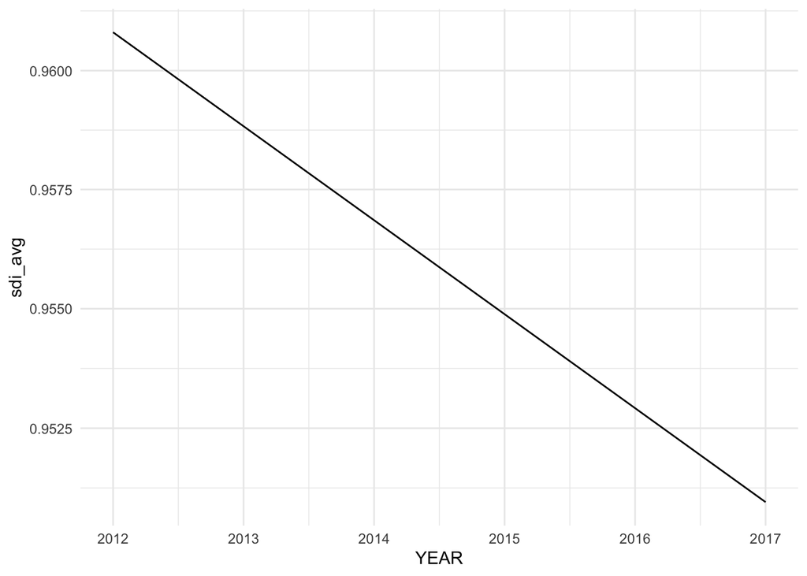

```r
div_new_sub <- subset(div_reclass, select=c(GEOID, YEAR, shannon_new, simpson_new, richness_new))
#div_2 <- div_2 %>% filter(YEAR %in% c(2008, 2009, 2010, 2011, 2012, 2013, 2014, 2015, 2016, 2017))
div_sum <- div_new_sub %>% group_by(YEAR) %>% mutate(sdi_avg = mean(shannon_new)) %>% mutate(sidi_avg = mean(simpson_new)) %>% mutate(rich_avg = mean(richness_new))

sdi_overall <- ggplot(div_sum, aes(x=YEAR, y = sdi_avg))+
  geom_line() +
  #geom_smooth(method=lm,color="red", fill="#69b3a2",se=TRUE)+
  scale_y_log10() +
  #xlim("2008","2017")+
  theme_minimal()

sidi_overall <- ggplot(div_sum, aes(x=YEAR, y = sidi_avg))+
  geom_line() +
  #geom_smooth(method=lm,color="blue", fill="#69b3a2",se=TRUE)+
  scale_y_log10() +
  #xlim("2008","2017")+
  theme_minimal()

rich_overall <- ggplot(div_sum, aes(x=YEAR, y = rich_avg))+
  geom_line() +
  #geom_smooth(method=lm,color="darkgreen", fill="#69b3a2",se=TRUE)+
  scale_y_log10() +
  #xlim("2008","2017")+
  theme_minimal()

par(mfrow=c(3,1))
sdi_overall
```

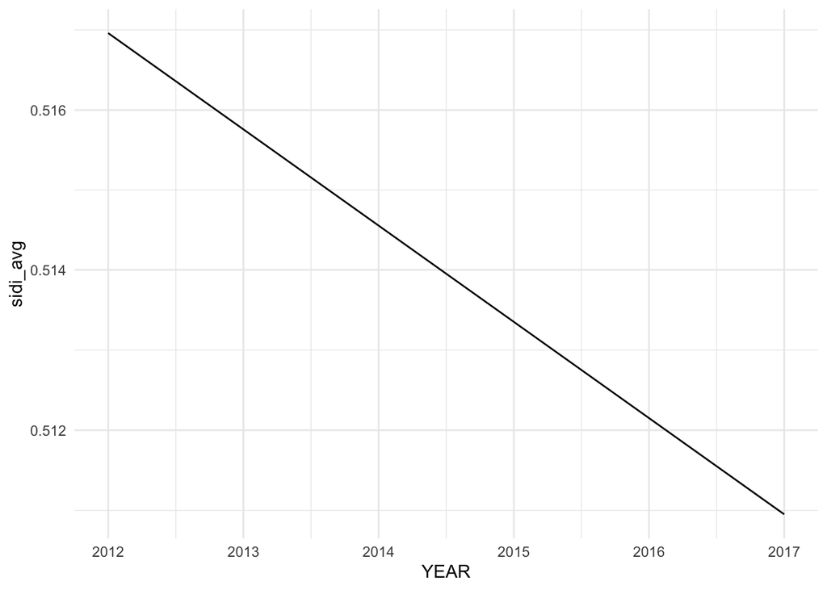

```r
sidi_overall
```

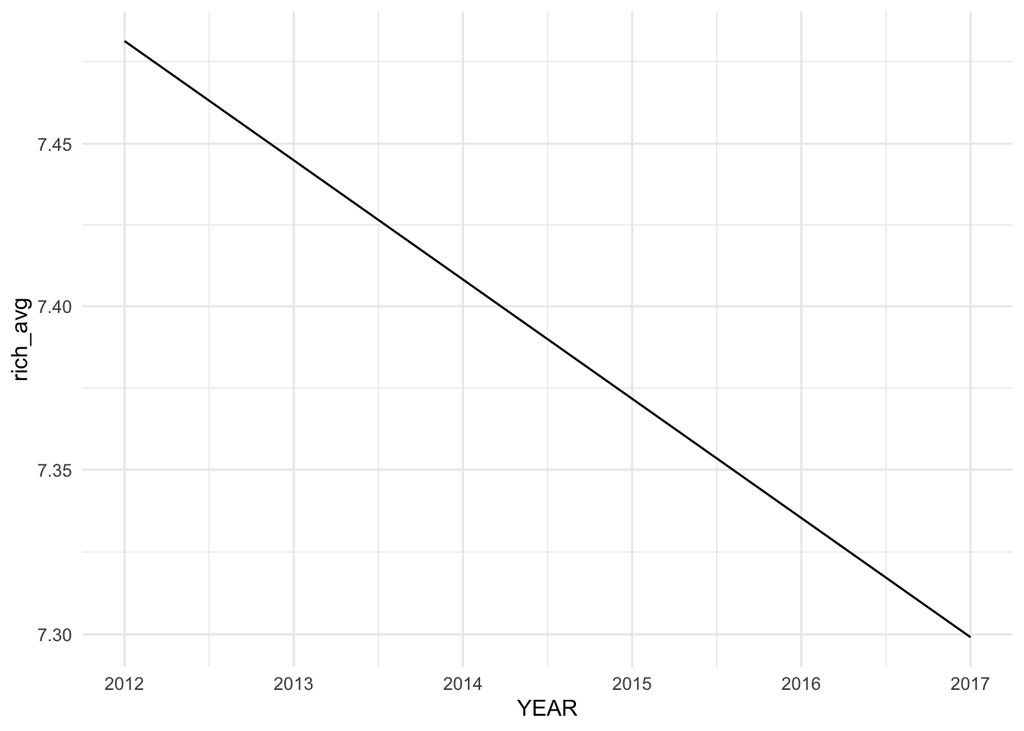

```r
rich_overall
```

## Data Availability

```r
#find % available
data_avail <- div_12 %>%
  summarize_all(funs(sum(is.na(.)) / length(.)))
#if you want to transpose, use the code below
t_d <- t(data_avail)

#find % available
data_avail2 <- div_17 %>%
  summarize_all(funs(sum(is.na(.)) / length(.)))
#if you want to transpose, use the code below
t_d2 <- t(data_avail2)

t_d
```

```
##                            [,1]
## GEOID              0.0000000000
## YEAR               0.0000000000
## county             0.0000000000
## RICH_CDL_AG        0.0000000000
## SDI_CDL_AG         0.0000000000
## SIDI_CDL_AG        0.0003217503
## age                0.0135135135
## female             0.0411840412
## male               0.0395752896
## full_owner         0.0527670528
## part_owner         0.0588803089
## tenant             0.0833333333
## exp                0.0135135135
## fert               0.0337837838
## fert_acres         0.0331402831
## manure_acres       0.0727155727
## chem               0.0450450450
## irrig              0.1007078507
## PERC_IRR           0.0640283140
## labor_n            0.0222007722
## labor_expense      0.0283140283
## machinery          0.0202702703
## perc_cl            0.0234877735
## perc_pe            0.0540540541
## acres_per_op       0.0148005148
## FRR                0.0000000000
## FRR_NAME           0.0000000000
## comm_sales         0.0276705277
## crop_sales         0.0608108108
## insur_acres        0.1087516088
## T_TEXTURE          0.0025740026
## REF_DEPTH          0.0019305019
## DRAINAGE           0.0022522523
## AWC_CLASS          0.0022522523
## PHASE1             0.8384813385
## ADD_PROP           0.0006435006
## T_GRAVEL           0.0000000000
## T_SAND             0.0000000000
## T_SILT             0.0000000000
```

[output cut: 28 more lines]

```
## BV15               0.0000000000
## BV16               0.0000000000
## BV17               0.0000000000
## BV18               0.0000000000
## BV19               0.0000000000
## shannon            0.0000000000
## shannon_new        0.0000000000
## shannon_double     0.0000000000
## simpson            0.0000000000
## simpson_new        0.0000000000
## simpson_double     0.0000000000
## richness           0.0000000000
## richness_new       0.0000000000
## richness_double    0.0000000000
## count              0.0000000000
```

```r
t_d2
```

```
##                            [,1]
## GEOID              0.0000000000
## YEAR               0.0000000000
## county             0.0000000000
## RICH_CDL_AG        0.0000000000
## SDI_CDL_AG         0.0000000000
## SIDI_CDL_AG        0.0012870013
## age                0.0141570142
## female             0.0234877735
## male               0.0202702703
## full_owner         0.0585585586
## part_owner         0.0315315315
## tenant             0.0743243243
## exp                0.0141570142
## fert               0.0276705277
## fert_acres         0.0244530245
## manure_acres       0.0595238095
## chem               0.0353925354
## irrig              0.0981338481
## PERC_IRR           0.0640283140
## labor_n            0.0183397683
## labor_expense      0.0247747748
## machinery          0.0180180180
## perc_cl            0.0199485199
## perc_pe            0.0492277992
## acres_per_op       0.0160875161
## FRR                0.0000000000
## FRR_NAME           0.0000000000
## comm_sales         0.0196267696
## crop_sales         0.0427927928
## insur_acres        0.1003861004
## T_TEXTURE          0.0025740026
## REF_DEPTH          0.0019305019
## DRAINAGE           0.0022522523
## AWC_CLASS          0.0022522523
## PHASE1             0.8384813385
## ADD_PROP           0.0006435006
## T_GRAVEL           0.0000000000
## T_SAND             0.0000000000
## T_SILT             0.0000000000
```

[output cut: 28 more lines]

```
## BV15               0.0000000000
## BV16               0.0000000000
## BV17               0.0000000000
## BV18               0.0000000000
## BV19               0.0000000000
## shannon            0.0000000000
## shannon_new        0.0000000000
## shannon_double     0.0000000000
## simpson            0.0000000000
## simpson_new        0.0000000000
## simpson_double     0.0000000000
## richness           0.0000000000
## richness_new       0.0000000000
## richness_double    0.0000000000
## count              0.0000000000
```

- irrig (2012: 10.1% missing, 2017: 9.8%)
- tenant (2012: 8.3% missing, 2017: 7.4%)
- PHASE1 (2012: 83.8% missing, 2017: 83.8%)
- insur_acres (2012: 10.9%, 2017: 10.0%)

## Pair-wise correlations

### Pair-Wise Correlation Matrix ~ Soil

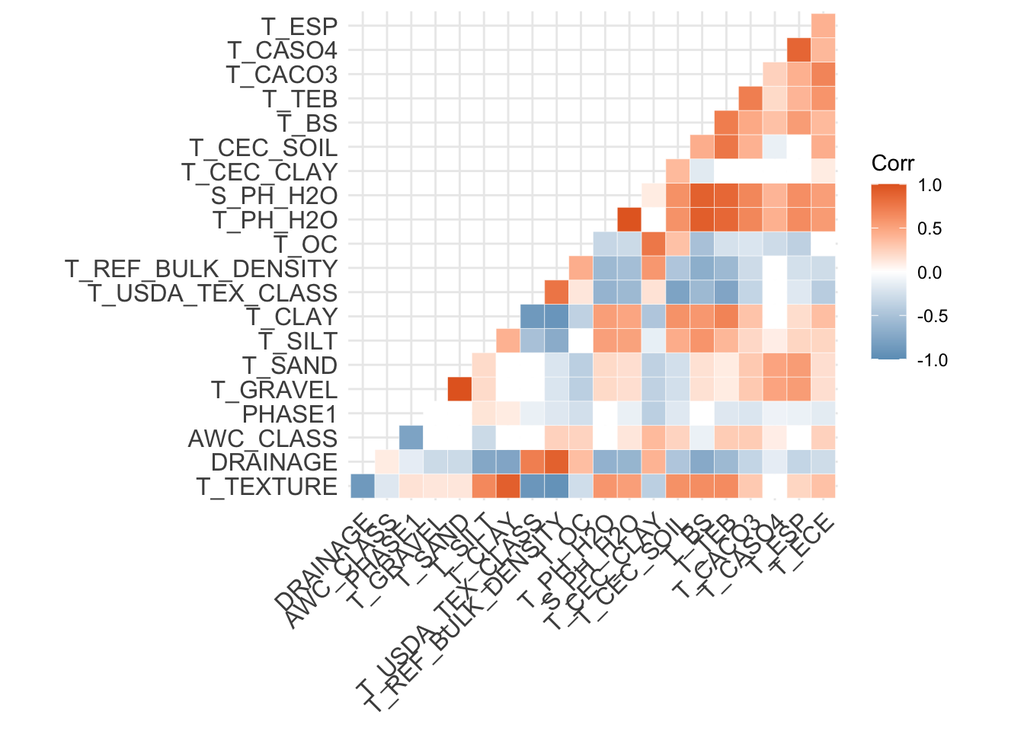

```r
# visualize by "natural" groupings of variables
# first, soil -- removing qualitative/coded variables T_TEXTURE, REF_DEPTH, DRAINAGE, AWC_CLASS, ADD_PROP, T_USDA_TEX_CLASS
soil <- div_12[c(31:53)]
soil <- soil[complete.cases(soil), ]
corr_soil <- round(cor(soil[c(1:23)]), 2)
p.mat_soil <- cor_pmat(soil[c(1:23)])
corrplot_soil <- ggcorrplot(corr_soil, hc.order = FALSE, p.mat = p.mat_soil, outline.col = "white", type = "lower", insig = "blank",lab = F, ggtheme = ggplot2::theme_minimal, colors = c("#6D9EC1", "white", "#E46726"))
corrplot_soil
```

```r
#output corrplot to jpg
ggsave(filename = "./for_manuscript/SI_figs/corrplot_soil.jpg", plot = corrplot_soil, dpi = 300, width = 8, height = 5)


# see initial correlations
red_soil <- as.data.frame(as.table(cor(soil[c(1:23)]), 1))
red_soil <- red_soil %>%  filter(Freq != 1) %>% mutate(aFreq = abs(Freq)) %>% arrange(desc(aFreq)) %>% filter(aFreq > 0.80) %>% dplyr::select(c(Var1, Var2, Freq))

knitr::kable(red_soil, caption = "Soil variable pairs with high correlation")
```

Soil variable pairs with high correlation

| Var1 | Var2 | Freq |
| --- | --- | --- |
| S_PH_H2O | T_PH_H2O | 0.9878652 |
| T_PH_H2O | S_PH_H2O | 0.9878652 |
| T_REF_BULK_DENSITY | T_TEXTURE | -0.9358169 |
| T_TEXTURE | T_REF_BULK_DENSITY | -0.9358169 |
| T_BS | T_PH_H2O | 0.9182507 |
| T_PH_H2O | T_BS | 0.9182507 |
| T_REF_BULK_DENSITY | T_CLAY | -0.9108654 |
| T_CLAY | T_REF_BULK_DENSITY | -0.9108654 |
| T_CLAY | T_TEXTURE | 0.9087884 |
| T_TEXTURE | T_CLAY | 0.9087884 |
| T_BS | S_PH_H2O | 0.9038008 |
| S_PH_H2O | T_BS | 0.9038008 |
| T_USDA_TEX_CLASS | T_TEXTURE | -0.9010420 |
| T_TEXTURE | T_USDA_TEX_CLASS | -0.9010420 |
| T_REF_BULK_DENSITY | DRAINAGE | 0.8991314 |
| DRAINAGE | T_REF_BULK_DENSITY | 0.8991314 |
| T_USDA_TEX_CLASS | T_CLAY | -0.8726074 |
| T_CLAY | T_USDA_TEX_CLASS | -0.8726074 |
| DRAINAGE | T_TEXTURE | -0.8697232 |
| T_TEXTURE | DRAINAGE | -0.8697232 |
| T_ESP | T_CASO4 | 0.8661373 |
| T_CASO4 | T_ESP | 0.8661373 |
| T_TEB | S_PH_H2O | 0.8633965 |
| S_PH_H2O | T_TEB | 0.8633965 |
| T_TEB | T_PH_H2O | 0.8587324 |
| T_PH_H2O | T_TEB | 0.8587324 |

Drop:

- T_PH_H2O
- T_TEB
- T_BS
- T_CLAY
- REF_DEPTH
- T_TEXTURE
- DRAINAGE
- AWC_CLASS
- ADD_PROP
- T_USDA_TEX_CLASS

### Pair-Wise Correlation Matrix ~ Climate

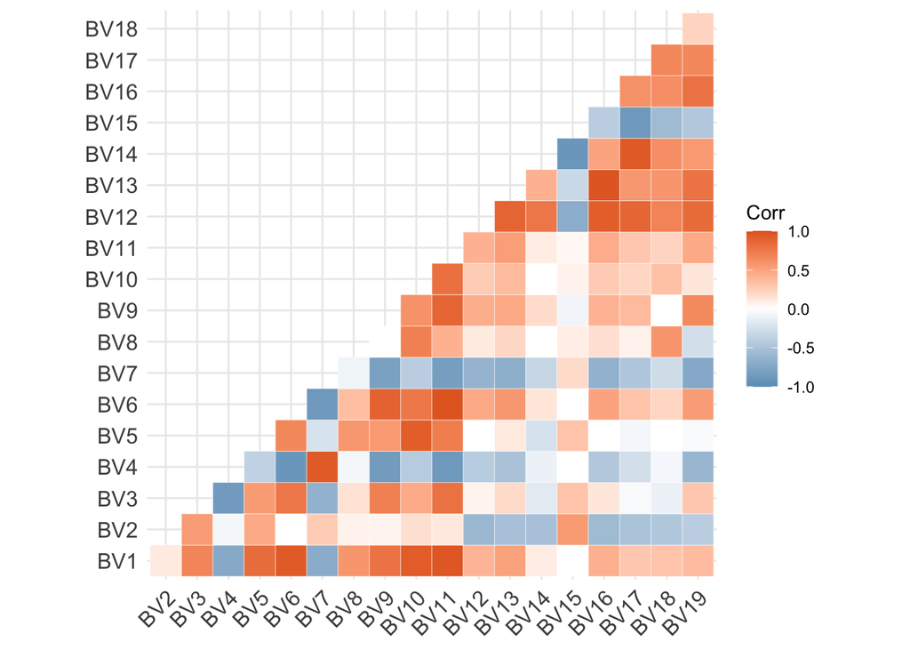

Climate variable pairs with high correlation

| Var1 | Var2 | Freq |
| --- | --- | --- |
| BV11 | BV6 | 0.9899915 |
| BV6 | BV11 | 0.9899915 |
| BV16 | BV13 | 0.9825282 |
| BV13 | BV16 | 0.9825282 |
| BV11 | BV1 | 0.9655243 |
| BV1 | BV11 | 0.9655243 |
| BV17 | BV14 | 0.9520946 |
| BV14 | BV17 | 0.9520946 |
| BV6 | BV1 | 0.9385433 |
| BV1 | BV6 | 0.9385433 |
| BV7 | BV4 | 0.9350770 |
| BV4 | BV7 | 0.9350770 |
| BV10 | BV1 | 0.9307302 |
| BV1 | BV10 | 0.9307302 |
| BV10 | BV5 | 0.9212287 |
| BV5 | BV10 | 0.9212287 |
| BV16 | BV12 | 0.9188533 |
| BV12 | BV16 | 0.9188533 |
| BV6 | BV4 | -0.8993989 |
| BV4 | BV6 | -0.8993989 |
| BV15 | BV14 | -0.8990688 |
| BV14 | BV15 | -0.8990688 |
| BV9 | BV6 | 0.8920840 |
| BV6 | BV9 | 0.8920840 |
| BV13 | BV12 | 0.8842805 |
| BV12 | BV13 | 0.8842805 |
| BV17 | BV15 | -0.8806538 |
| BV15 | BV17 | -0.8806538 |
| BV7 | BV6 | -0.8799272 |
| BV6 | BV7 | -0.8799272 |
| BV11 | BV4 | -0.8750340 |
| BV4 | BV11 | -0.8750340 |
| BV11 | BV9 | 0.8692683 |
| BV9 | BV11 | 0.8692683 |
| BV17 | BV12 | 0.8689110 |
| BV12 | BV17 | 0.8689110 |
| BV4 | BV3 | -0.8563608 |
| BV3 | BV4 | -0.8563608 |
| BV9 | BV4 | -0.8487938 |
| BV4 | BV9 | -0.8487938 |
| BV19 | BV12 | 0.8353876 |
| BV12 | BV19 | 0.8353876 |
| BV5 | BV1 | 0.8296647 |
| BV1 | BV5 | 0.8296647 |
| BV11 | BV7 | -0.8271132 |
| BV7 | BV11 | -0.8271132 |
| BV11 | BV10 | 0.8089971 |
| BV10 | BV11 | 0.8089971 |
| BV9 | BV7 | -0.8035085 |
| BV7 | BV9 | -0.8035085 |

- Whenever there was a choice between quarter and month, I chose quarter
- If it was a choice between total precip or mean temp. and a quarterly metric, I chose the total annual value as it would be less sensitive
- There were some choices between two quarter values (mean temp of wettest vs. coldest quarter), so I chose the one that was correlated with other variables as well (although this got a little messy)

Drop:

BV14 BV13 BV6 BV17 BV19 BV16 BV5 BV11

### Pair-Wise Correlation Matrix ~ COA

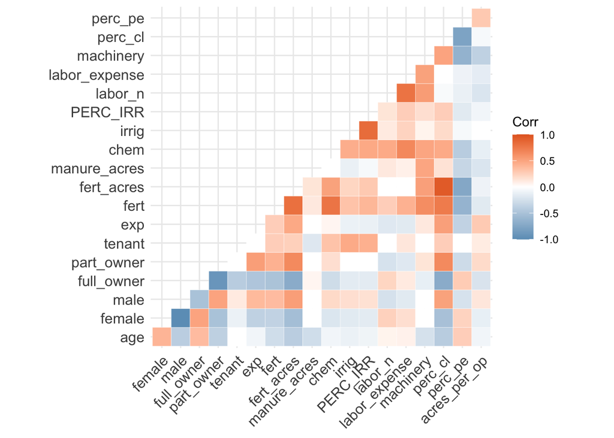

COA variable pairs with high correlation

| Var1 | Var2 | Freq |
| --- | --- | --- |
| male | female | -1.0000000 |
| female | male | -1.0000000 |
| perc_cl | fert_acres | 0.9390556 |
| fert_acres | perc_cl | 0.9390556 |
| part_owner | full_owner | -0.9144376 |
| full_owner | part_owner | -0.9144376 |
| PERC_IRR | irrig | 0.8277955 |
| irrig | PERC_IRR | 0.8277955 |
| fert_acres | fert | 0.8148466 |
| fert | fert_acres | 0.8148466 |

Drop:

- female (male has greater availability across the two years)
- full_owner (part_owner has greater availability across the two years)
- labor_expense (labor_n has greater availability across the two years)
- fert_acres (perc_cl has greater availability than fert_acres and fert_acres/fert are VERY close)
- crop_sales (chem has greater availability than crop_sales)

## Variable selection

### Remove missing variables

```r
#Row-wise delete missing data

#2012
drops <- c("PHASE1", "irrig", "tenant", "insur_acres")
div_12 <- div_12[ , !(names(div_12) %in% drops)]

#2017
div_17 <- div_17[ , !(names(div_17) %in% drops)]
```

### Remove variables that are linear products of other variables

```r
#BV3 is a direct product of BV2 and BV7
#BV7 is a direct product of BV5 and BV6
div_12 <- div_12 %>% dplyr::select(-c("BV3", "BV7"))

div_17 <- div_17 %>% dplyr::select(-c("BV3", "BV7"))
```

### Remove correlated soil variables

```r
div_12 <- div_12 %>% dplyr::select(-c("T_PH_H2O", "T_TEB", "T_BS", "T_CLAY"))

div_17 <- div_17 %>% dplyr::select(-c("T_PH_H2O", "T_TEB", "T_BS", "T_CLAY"))
```

These are also more difficult to interpret/qualitative soil variables that are a bit redundant and ranked by J. Cowan as 2-3 (medium to low priority)

```r
div_12 <- div_12 %>% dplyr::select(-c("DRAINAGE", "T_USDA_TEX_CLASS", "T_TEXTURE", "REF_DEPTH", "AWC_CLASS", "ADD_PROP"))

div_17 <- div_17 %>% dplyr::select(-c("DRAINAGE", "T_USDA_TEX_CLASS", "T_TEXTURE", "REF_DEPTH", "AWC_CLASS", "ADD_PROP"))
```

#### Remove correlated climate variables

```r
div_12 <- div_12 %>% dplyr::select(-c("BV14", "BV13", "BV6","BV17", "BV19", "BV16", "BV5", "BV11"))

div_17 <- div_17 %>% dplyr::select(-c("BV14", "BV13", "BV6","BV17", "BV19", "BV16", "BV5", "BV11"))
```

#### Remove correlated COA variables

```r
div_12 <- div_12 %>% dplyr::select(-c("female", "full_owner","labor_expense","fert_acres", "crop_sales"))

div_17 <- div_17 %>% dplyr::select(-c("female", "full_owner","labor_expense","fert_acres", "crop_sales"))
```